# BigMart Sales & Inventory Performance Analysis

Sheila

2026-08-19

## Set up and SQLite Engine Initialization

```r
bigmart<-read.csv("Train.csv")
con <- dbConnect(SQLite(), "bigmart.db")

dbWriteTable(con, "sales", bigmart, overwrite = TRUE)
```

## Business Problem:

- **BigMart operates a nationwide retail network where managing inventory mix and optimizing sales across diverse product categories presents a major operational challenge. Inefficient stock allocation across different outlet formats risks tied-up capital and missed revenue opportunities.

## Business Objective:

- ** To evaluate the core drivers of item-level retail performance by quantifying how product attributes (pricing, category composition, fat content) and store characteristics (outlet format, store size) impact revenue generation across locations.

## Executive Summary:

- **An evaluation of 8,523 SKU-level records across BigMart retail locations reveals that total revenue performance across product categories, fat content, and store formats is primarily driven by catalog composition and volume density rather than per-unit performance variations. However, structural efficiencies exist in store design: Supermarket Type3 and Medium-sized outlets demonstrate true operational outperformance, generating significantly higher revenue per item. Strategic focus should prioritize expanding high-efficiency formats and optimizing SKU breadth rather than relying on category-level repricing.

## Data Cleaning and Feature Engineering

```r
# Data cleaning via SQLite view
dbExecute(con, "DROP VIEW IF EXISTS clean_sales")
```

```
## [1] 0
```

```r
dbExecute(con, "
  CREATE VIEW clean_sales AS
  SELECT *,
    CASE
      WHEN Item_Fat_Content IN ('low fat', 'LF') THEN 'Low Fat'
      WHEN Item_Fat_Content = 'reg' THEN 'Regular'
      ELSE Item_Fat_Content
    END AS Clean_Fat_Content,
    CASE
      WHEN Outlet_Size = '' OR Outlet_Size IS NULL THEN 'Unknown'
      ELSE Outlet_Size
    END AS Clean_Outlet_Size
  FROM sales
")
```

```
## [1] 0
```

```r
bigmart_clean <- dbGetQuery(con, "SELECT * FROM clean_sales")
str(bigmart_clean)
```

```
## 'data.frame':    8523 obs. of  14 variables:
##  $ Item_Identifier          : chr  "FDA15" "DRC01" "FDN15" "FDX07" ...
##  $ Item_Weight              : num  9.3 5.92 17.5 19.2 8.93 ...
##  $ Item_Fat_Content         : chr  "Low Fat" "Regular" "Low Fat" "Regular" ...
##  $ Item_Visibility          : num  0.016 0.0193 0.0168 0 0 ...
##  $ Item_Type                : chr  "Dairy" "Soft Drinks" "Meat" "Fruits and Vegetables" ...
##  $ Item_MRP                 : num  249.8 48.3 141.6 182.1 53.9 ...
##  $ Outlet_Identifier        : chr  "OUT049" "OUT018" "OUT049" "OUT010" ...
##  $ Outlet_Establishment_Year: int  1999 2009 1999 1998 1987 2009 1987 1985 2002 2007 ...
##  $ Outlet_Size              : chr  "Medium" "Medium" "Medium" "" ...
##  $ Outlet_Location_Type     : chr  "Tier 1" "Tier 3" "Tier 1" "Tier 3" ...
##  $ Outlet_Type              : chr  "Supermarket Type1" "Supermarket Type2" "Supermarket Type1" "Grocery Store" ...
##  $ Item_Outlet_Sales        : num  3735 443 2097 732 995 ...
##  $ Clean_Fat_Content        : chr  "Low Fat" "Regular" "Low Fat" "Regular" ...
##  $ Clean_Outlet_Size        : chr  "Medium" "Medium" "Medium" "Unknown" ...
```

```r
# Check extent of missing/blank data before relying on cleaned columns
missing_check <- dbGetQuery(con, "
  SELECT
    SUM(CASE WHEN Outlet_Size = '' OR Outlet_Size IS NULL THEN 1 ELSE 0 END) AS n_unknown_size,
    SUM(CASE WHEN Item_Weight IS NULL THEN 1 ELSE 0 END) AS n_missing_weight,
    COUNT(*) AS total_rows
  FROM sales
")
missing_check
```

```
##   n_unknown_size n_missing_weight total_rows
## 1           2410             1463       8523
```

## Revenue by fat content

```r
fat_pct_analysis <- dbGetQuery(con, "
    SELECT Clean_Fat_Content,
    SUM(Item_Outlet_Sales) AS total_revenue,
    ROUND(SUM(Item_Outlet_Sales) * 100.0 / (SELECT SUM(Item_Outlet_Sales) FROM clean_sales), 1) AS pct_of_total_revenue
FROM clean_sales
GROUP BY Clean_Fat_Content")

dbGetQuery(con, "
  SELECT Clean_Fat_Content,
         COUNT(*) AS n_items,
         AVG(Item_Outlet_Sales) AS avg_revenue_per_item
  FROM clean_sales
  GROUP BY Clean_Fat_Content
")
```

```
##   Clean_Fat_Content n_items avg_revenue_per_item
## 1           Low Fat    5517             2157.712
## 2           Regular    3006             2224.561
```

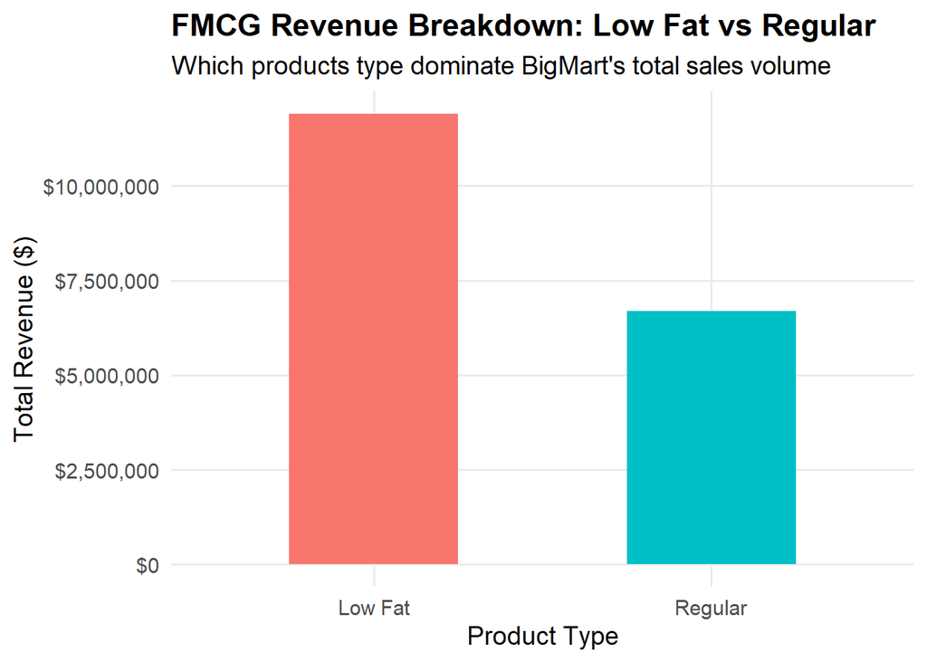

```r
ggplot(fat_pct_analysis, aes(x = Clean_Fat_Content, y = total_revenue, fill = Clean_Fat_Content)) +
  geom_col(width = 0.5, show.legend = FALSE) +
  scale_y_continuous(labels = label_dollar()) + # Formats axis as $10M, $5M, etc.
  theme_minimal(base_size = 14) + # Clean, modern background style
  labs(
    title = "FMCG Revenue Breakdown: Low Fat vs Regular",
    subtitle = "Which products type dominate BigMart's total sales volume",
    x = "Product Type",
    y = "Total Revenue ($)"
  ) +
  theme(
    plot.title = element_text(face = "bold"),
    panel.grid.minor = element_blank()
  )
```

```r
dir.create("outputs", showWarnings = FALSE)
ggsave("outputs/fat_content_revenue.png", width = 8, height = 5, dpi = 150)
```

> **Key Insight:** Low Fat products account for **64% of total revenue ($11.9M)** compared to 36% for Regular items ($6.7M). However, this gap is driven almost entirely by catalog composition (64.7% of total SKUs are Low Fat) rather than superior per-item sales performance.

## Revenue by Outlet_type

```r
Outlet_type_analysis<-dbGetQuery(con, "
SELECT Outlet_Type,
  COUNT(*) AS n_items,
  SUM(Item_Outlet_Sales) AS total_revenue,
  AVG(Item_Outlet_Sales) AS avg_revenue_per_item
FROM clean_sales
GROUP BY Outlet_Type
ORDER BY total_revenue DESC
")

dbGetQuery(con, "
  SELECT Outlet_Type,
         COUNT(*) AS n_items,
         AVG(Item_Outlet_Sales) AS avg_revenue_per_item
  FROM clean_sales
  GROUP BY Outlet_Type
")
```

```
##         Outlet_Type n_items avg_revenue_per_item
## 1     Grocery Store    1083             339.8285
## 2 Supermarket Type1    5577            2316.1811
## 3 Supermarket Type2     928            1995.4987
## 4 Supermarket Type3     935            3694.0386
```

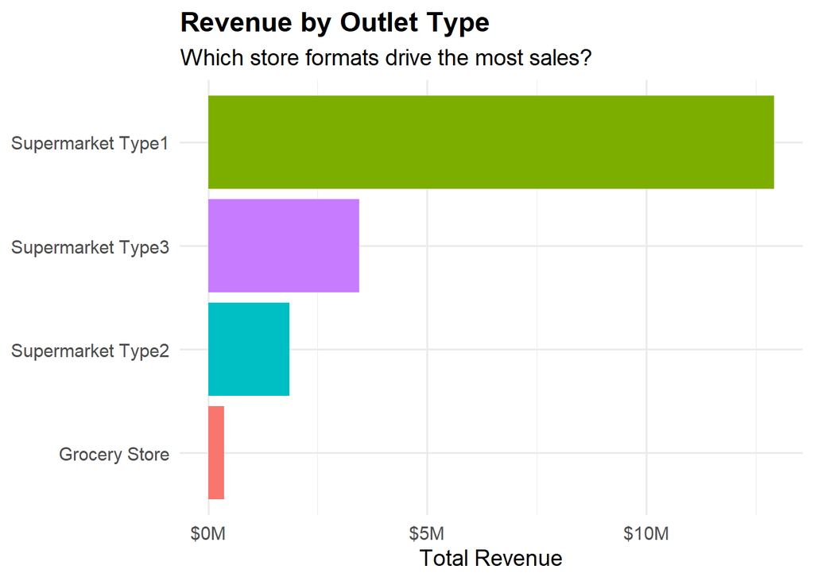

```r
ggplot(Outlet_type_analysis, aes(x = reorder(Outlet_Type, total_revenue), y = total_revenue, fill = Outlet_Type)) +
  geom_col(show.legend = FALSE) +
  coord_flip() +
  scale_y_continuous(labels = label_dollar(scale = 1e-6, suffix = "M")) +
  theme_minimal(base_size = 14) +
  labs(
    title = "Revenue by Outlet Type",
    subtitle = "Which store formats drive the most sales?",
    x = NULL,
    y = "Total Revenue"
  ) +
  theme(plot.title = element_text(face = "bold"))
```

```r
dir.create("outputs", showWarnings = FALSE)
ggsave("outputs/Outlet_type_revenue.png", width = 8, height = 5, dpi = 150)
```

> **Key Insight:** **Supermarket Type1** drives overall volume, generating **$12.9M (69.5% of total revenue)** across 5,577 items. However, **Supermarket Type3** exhibits superior per-item sales efficiency, averaging **$3,694 per SKU** compared to Type1’s **$2,316**, despite operating with 83% fewer items (935 SKUs). Grocery Stores represent a low-margin format, averaging just $340 per item and contributing 2% of total revenue.

## Revenue by outlet_size

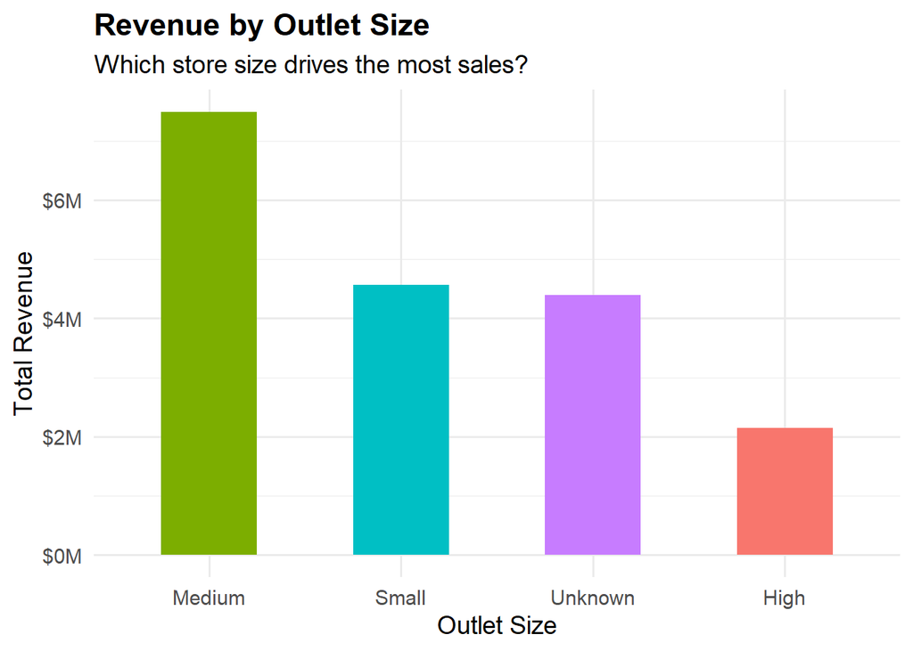

```r
Outlet_size_analysis<-dbGetQuery(con, "
        SELECT Clean_Outlet_Size,
        COUNT(*) AS n_items,
        SUM(Item_Outlet_Sales) AS total_revenue,
        AVG(Item_Outlet_Sales) AS agv_revenue_per_item
        FROM clean_sales
        GROUP BY Clean_Outlet_Size
        ORDER BY total_revenue DESC
        ")
ggplot(Outlet_size_analysis, aes(x = reorder(Clean_Outlet_Size, -total_revenue), y = total_revenue, fill = Clean_Outlet_Size)) +
  geom_col(width = 0.5, show.legend = FALSE) +
  scale_y_continuous(labels = label_dollar(scale = 1e-6, suffix = "M")) +
  theme_minimal(base_size = 14) +
  labs(
    title = "Revenue by Outlet Size",
    subtitle = "Which store size drives the most sales?",
    x = "Outlet Size",
    y = "Total Revenue"
  ) +
  theme(plot.title = element_text(face = "bold")
        )
```

```r
dir.create("outputs", showWarnings = FALSE)
ggsave("outputs/Outlet_size_revenue.png", width = 8, height = 5, dpi = 150)
```

> **Key Insight:** **Medium-sized outlets** lead across all formats, generating **$7.49M (40.3% of total revenue)** and achieving the highest yield at **$2,682 per item**. Unlike catalog volume effects, Medium stores demonstrate genuine operational outperformance. Notably, High-sized outlets post the second-highest average per-item yield ($2,299) despite managing the fewest total items (932 SKUs).

> *Note:* **28.3% of records (2,410 items)** lacked outlet size data and were coded as “Unknown”. Final footprint strategy should account for this structural gap.

## Revenue by Item-Type

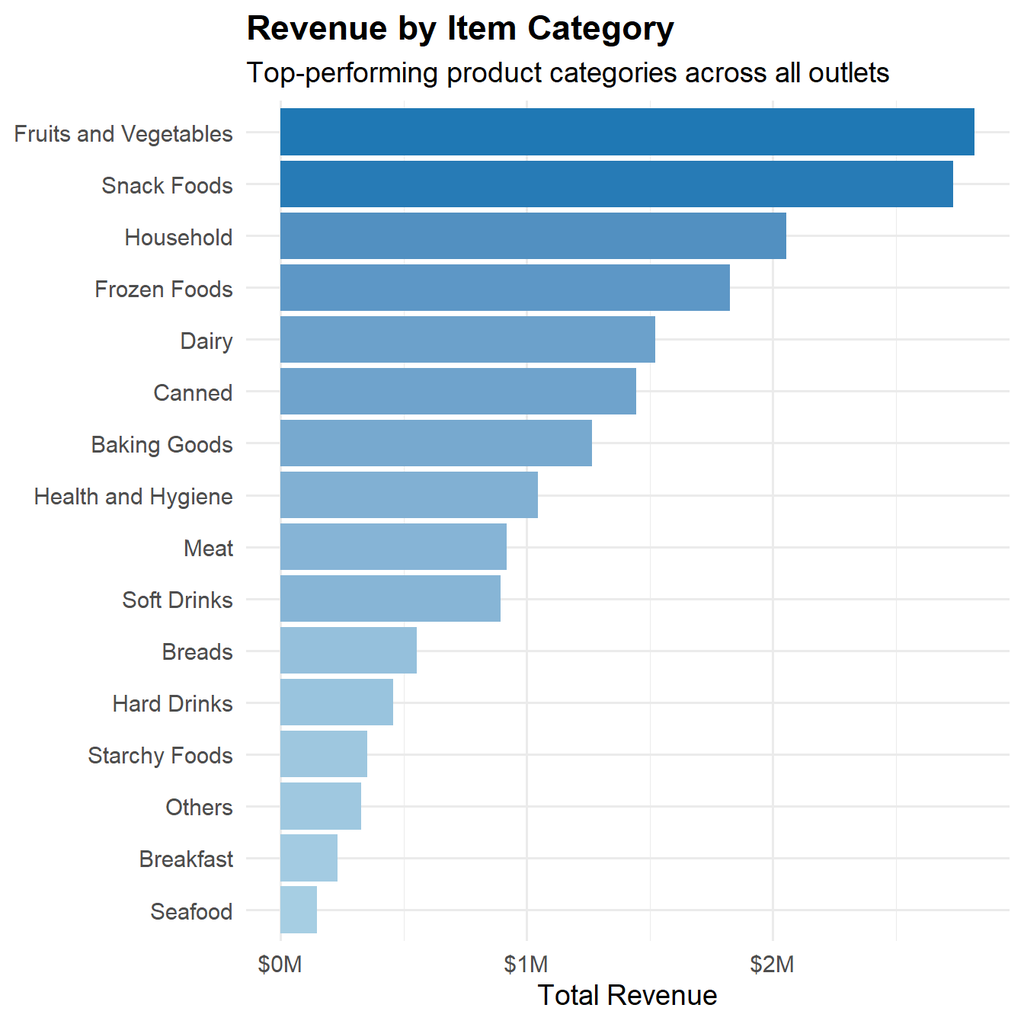

```r
Item_type_analysis<-dbGetQuery(con,"
    SELECT Item_Type,
    COUNT(*) AS n_items,
    SUM(Item_Outlet_Sales) AS total_revenue,
    AVG(Item_Outlet_Sales) AS agv_revenue_per_item
  FROM clean_sales
  GROUP BY Item_Type
  ORDER BY total_revenue DESC
    ")
ggplot(Item_type_analysis, aes(x=reorder(Item_Type, total_revenue), y=
total_revenue, fill = total_revenue)) +
  geom_col(show.legend = FALSE) +
  coord_flip() +
  scale_y_continuous(labels = label_dollar(scale = 1e-6, suffix = "M")) +
  scale_fill_gradient(low = "#a6cee3", high = "#1f78b4" ) +
  theme_minimal(base_size = 14) +
  labs(
    title = "Revenue by Item Category",
    subtitle = "Top-performing product categories across all outlets",
    x = NULL,
    y = "Total Revenue"
  ) +
  theme(plot.title = element_text(face = "bold"))
```

```r
dir.create("outputs", showWarnings = FALSE)
ggsave("outputs/Item_type_revenue.png", width = 8, height = 5, dpi = 150)
```

> **Key Insight:** **Fruits and Vegetables ($2.82M)** and **Snack Foods ($2.73M)** lead gross sales, with nearly identical SKU allocations (~1,200 items each). However, per-item yield remains remarkably uniform across all 16 categories, ranging strictly between **$1,900 and $2,400 per SKU** (e.g., Seafood generates $2,326 per item across just 64 SKUs). This indicates category revenue is dictated by stock allocation volume rather than consumer price premiums or category-specific demand elasticity.

## Price Vs. Sales Relationships

```r
Price_sales<-dbGetQuery(con, "
 SELECT Item_MRP, Item_Outlet_Sales, Clean_Fat_Content
 FROM clean_sales
 ")

cor(Price_sales$Item_MRP, Price_sales$Item_Outlet_Sales)
```

```
## [1] 0.5675744
```

```r
#splitting by fat content
Price_sales%>%
  group_by(Clean_Fat_Content)%>%
  summarise(correlation = cor(Item_MRP, Item_Outlet_Sales))
```

```
## # A tibble: 2 × 2
##   Clean_Fat_Content correlation
##   <chr>                   <dbl>
## 1 Low Fat                 0.563
## 2 Regular                 0.576
```

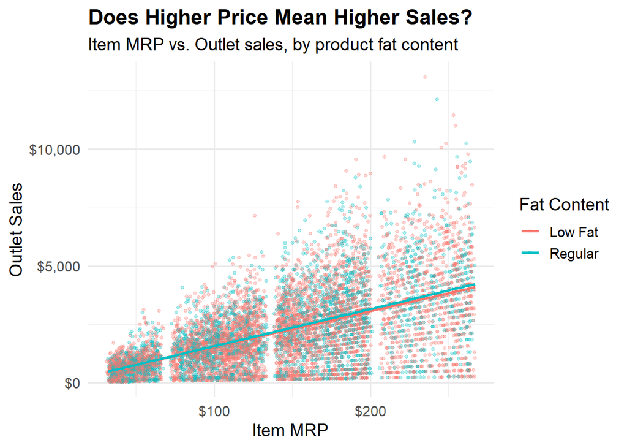

```r
ggplot(Price_sales, aes(x = Item_MRP, y = Item_Outlet_Sales, colour =
Clean_Fat_Content)) +
 geom_point(alpha = 0.3, size = 1) +
 geom_smooth(method = "lm", se = FALSE, linewidth = 1) +
  scale_y_continuous(labels = label_dollar()) +
  scale_x_continuous(labels = label_dollar()) +
  theme_minimal(base_size = 14) +
  labs(
    title = "Does Higher Price Mean Higher Sales?",
    subtitle = "Item MRP vs. Outlet sales, by product fat content",
    x= "Item MRP",
    y="Outlet Sales",
    color = "Fat Content"
  )+
  theme(plot.title = element_text(face = "bold"))
```

```r
dir.create("outputs", showWarnings = FALSE)
ggsave("outputs/Price_sales$Item_MRP correlation.png", width = 8, height = 5, dpi = 150)
```

> **Key Insight:** A moderate positive correlation exists between Maximum Retail Price (Item_MRP) and sales (**r = 0.57, R² ≈ 0.32**), indicating that higher-priced items generate more overall revenue, though price alone explains only about a third of sales variation. This pricing dynamic is consistent across product segments (**Low Fat: 0.563 vs. Regular: 0.576**), demonstrating that fat content does not alter how price drives sales.

## Sales by Outlet Establishment Year

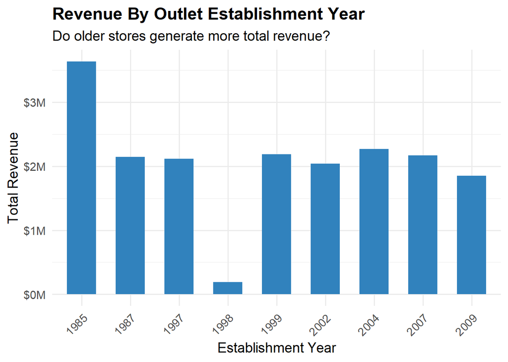

```r
Year_analysis<-dbGetQuery(con, "
  SELECT Outlet_Establishment_Year, SUM(Item_Outlet_Sales) AS total_revenue,
  AVG(Item_Outlet_Sales) AS avg_revenue_per_item
  FROM clean_sales
  GROUP BY Outlet_Establishment_Year
  ORDER BY Outlet_Establishment_Year
")

ggplot(Year_analysis, aes(x = factor(Outlet_Establishment_Year), y = total_revenue)) +
  geom_col(fill = "#3182bd", width = 0.6 ) +
  scale_y_continuous(labels = label_dollar(scale = 1e-6, suffix = "M")) +
  theme_minimal(base_size = 14) +
  labs(
    title = "Revenue By Outlet Establishment Year",
    subtitle= "Do older stores generate more total revenue?",
    x= "Establishment Year",
    y= "Total Revenue"
  ) +
  theme(
    plot.title = element_text(face = "bold"),
    axis.text.x = element_text(angle = 45, hjust = 1)
  )
```

```r
dir.create("outputs", showWarnings = FALSE)
ggsave("outputs/Item_Outlet_Sales_revenue.png", width = 8, height = 5, dpi = 150)
```

```r
list.files("outputs")
```

```
## [1] "fat_content_revenue.png"
## [2] "Item_Outlet_Sales_revenue.png"
## [3] "item_type_revenue.png"
## [4] "outlet_size_revenue.png"
## [5] "outlet_type_revenue.png"
## [6] "Price_sales$Item_MRP correlation.png"
## [7] "price_vs_sales.png"
```

```r
file.rename("outputs/fat_content_revenue.png", "outputs/fat_content_revenue.png")
```

```
## [1] TRUE
```

```r
file.rename("outputs/Outlet_type_revenue.png", "outputs/outlet_type_revenue.png")
```

```
## [1] TRUE
```

```r
file.rename("outputs/Outlet_size_revenue.png", "outputs/outlet_size_revenue.png")
```

```
## [1] TRUE
```

```r
file.rename("outputs/Item_type_revenue.png", "outputs/item_type_revenue.png")
```

```
## [1] TRUE
```

```r
file.rename("outputs/Item_Outlet_Sales_revenue.png", "outputs/price_vs_sales.png")
```

```
## [1] TRUE
```

```r
file.remove("outputs/Price_sales$Item_MRP correlation.png")
```

```
## [1] TRUE
```

```r
list.files("outputs")
```

```
## [1] "fat_content_revenue.png" "item_type_revenue.png"
## [3] "outlet_size_revenue.png" "outlet_type_revenue.png"
## [5] "price_vs_sales.png"
```

## Session Clean-up

```r
dbDisconnect(con)
```

**Data Source:** BigMart Sales dataset (‘Train.csv’) **Tech Stack:** R, SQLite, (DBI/RSQLite), readr, ggplot2, dplyr, magrittr, scales